# Trabalho final "Mineração de dados"

## 1 Árvores de decisão

Considere o conjunto de dados `iris.csv` que contém os dados sobre 3 tipos de flores diferentes: `Iris-setosa`, `Iris-versicolor` e `Iris-virginica`. 4 variávies sobre cada registro estão disponíveis, referentes aos tamanhos das sépalas e pétalas das flores. Deseja-se classificar o tipo de flor (`target`) com base nos tamanhos, porém **sem considerar** o `petal width`. Faça o que se pede:

1. Gere um modelo de classificação por meio de uma árvore de decisão. Use a validação cruzada com k=10 *folds*, e otimize os parâmetros referentes ao tamanho máximo da árvore e o critério de medição da qualidade de um nó (com `gini` e `entropy`). Para cada critério de medição de qualidade, armazene os erros de treino e teste para os diferentes tamanhos de árvore, e plote em dois gráficos (na mesma figura). Os gráficos devem ficar da seguinte forma:

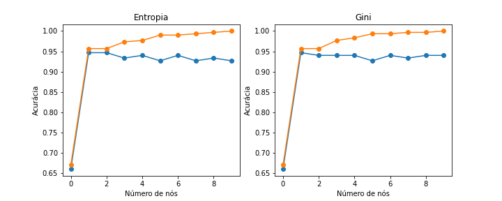

1. Verifique qual o melhor conjunto de parâmetros e estime uma nova árvore com todos os dados. Imprima a de forma visual, com os nomes das classes e dos atributos. A Figura deve ficar como a árvore a seguir:

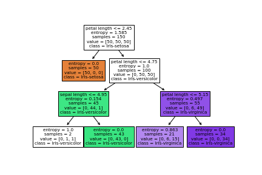

## 2 Agrupamento

Considere o conjunto de dados `clientes_shopping.csv`. Este conjunto contém os dados de diversos clientes de um Shoppping center. O shopping deseja fazer uma segmentação dos clientes para criar uma campanha de marketing mais efetiva. Implemente a segmentação usando o algoritmo k-means, com base em todos os atributos (exceto CustumerID).

1. Aplique todas as transformações necessárias no banco para aplicar o algoritmo.
2. Encontre o número ideal de grupos.
3. Use a decomposição de componentes principais para plotar um scatter plot dos diferentes grupos criados